# Monitoramento Funil Blend4

## Execução

```
Última execução: 13/11/2026 11:21:44 -03
```

## Diretório e Configurações

## Base: Blend4 em Produção

```
Volume total (simulação): 608,687
Contratos únicos: 608,687
Período: 2026-07-01 00:00:00 → 2026-11-12 00:00:00
```

```
bureau_nm_ajust
BLEND3                  232289
BLEND4                  374868
BLEND_REGRESSAO_2026      1278
NaN                        252
dtype: int64
```

## Diário e Semanal

```
Diário simulação: 2026-11-05 00:00:00 → 2026-11-12 00:00:00 | n=40,627
```

```
Semanal simulação: 2026-10-04 00:00:00 → 2026-11-12 00:00:00 | n=170,723
```

## Multiproponente vs. Uniproponente

Proporção de Multipronentes vs. Uniproponentes ao longo das semanas. O esperado é algo entre 3-4%.

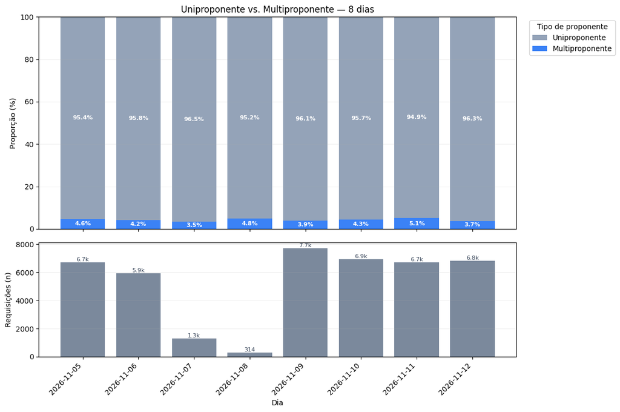

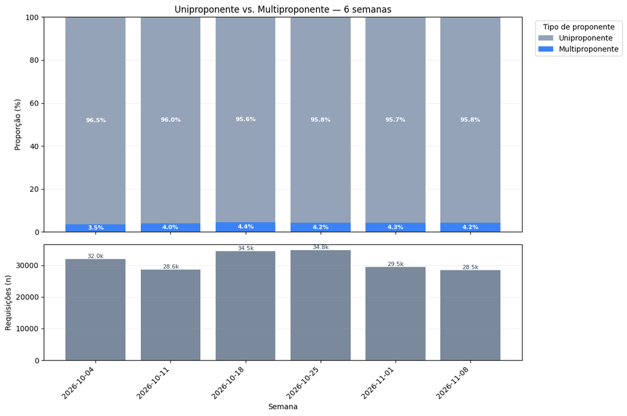

# Uniproponentes

A partir daqui, seguimos apenas com o público Uniproponente.

## Mix de Modelos Diário e Semanal

Mix de Modelos dividido entre Blend3, Blend4 e Fallback. Blend2 foi descontinuado e deu lugar ao Blend4.

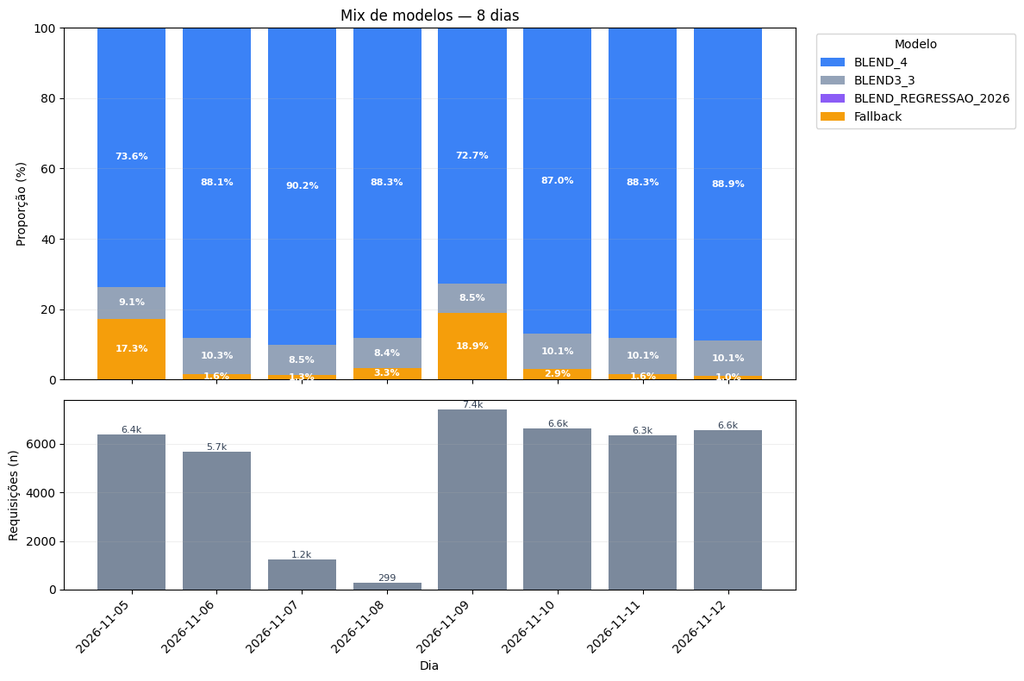

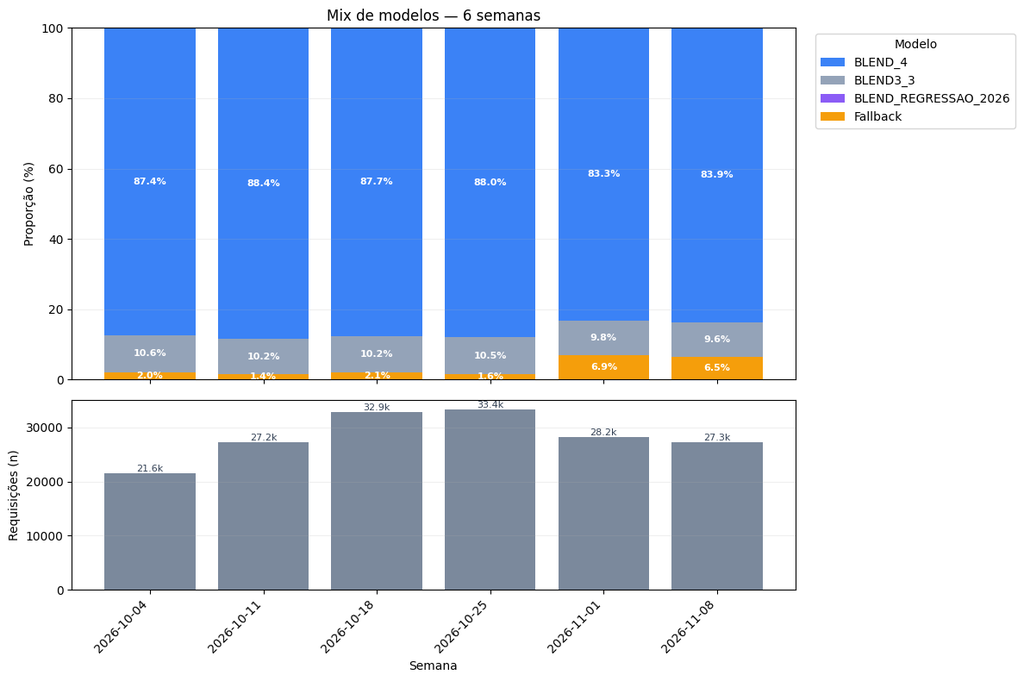

## Mix de Modelos Diário e Semanal

Nesta etapa, retiramos o público que é FALLBACK e seguimos apenas com as comparações entre os Blend's que estão em produção (Blend 3 Blend4).

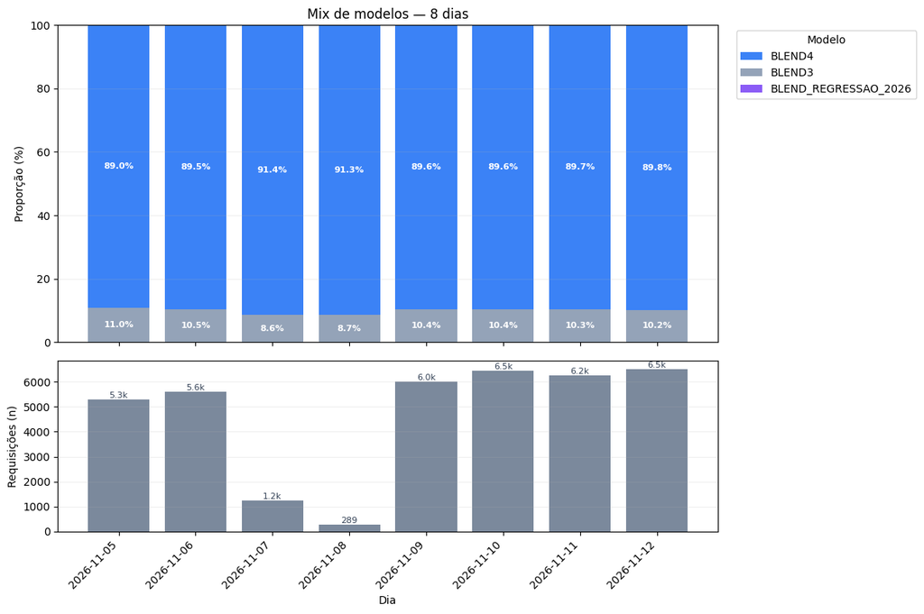

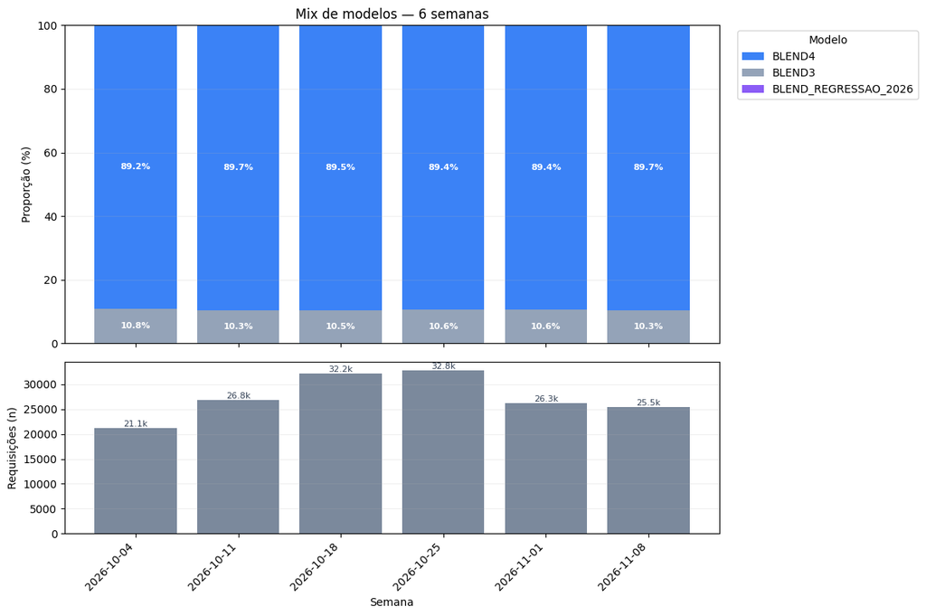

## Pré-Análise

Comparação do percentual de Aprovados, Derivados e Reprovados do Blend3 e Blend4.

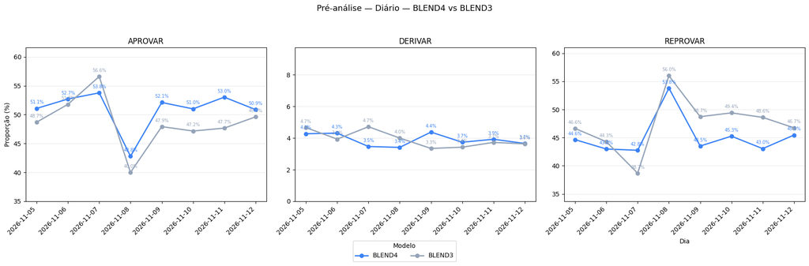

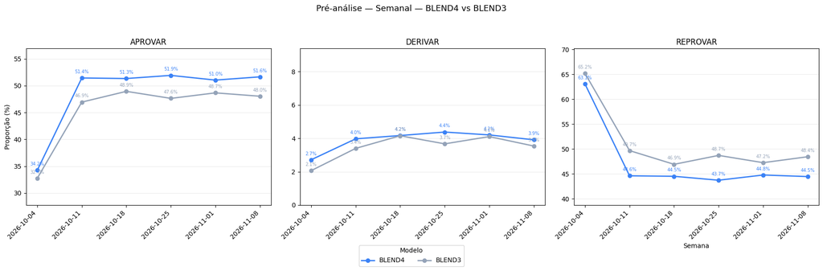

## Pré-Análise sem o Público Rating E do Blend3

Nesse caso, tiramos a elegibilidade do público que é Rating E do Blend 3.

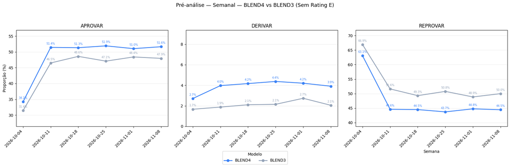

## Funil

Comparação entre Blend3 e Blend4 em relação a Elegbilidade, Envio, Atiavação e Conversão.

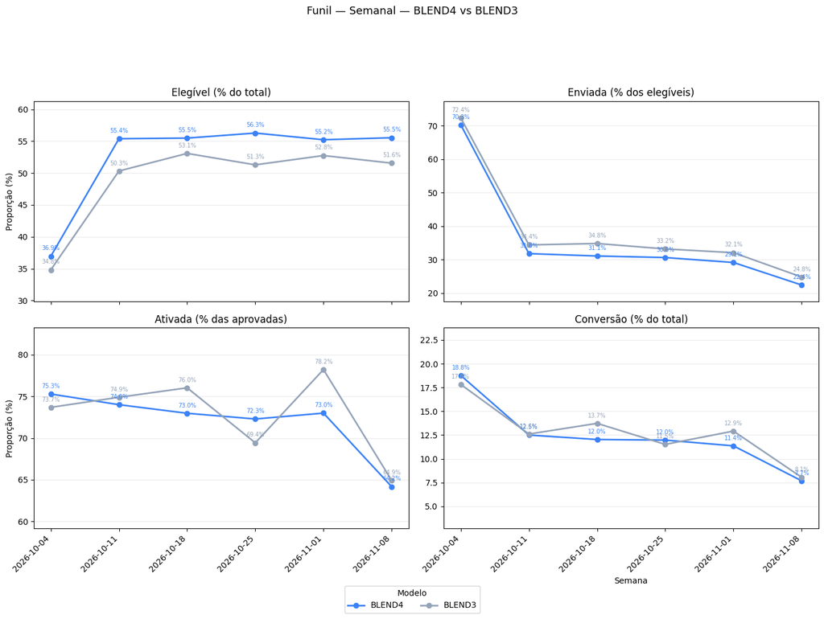

## Funil sem o Rating E do Blend3

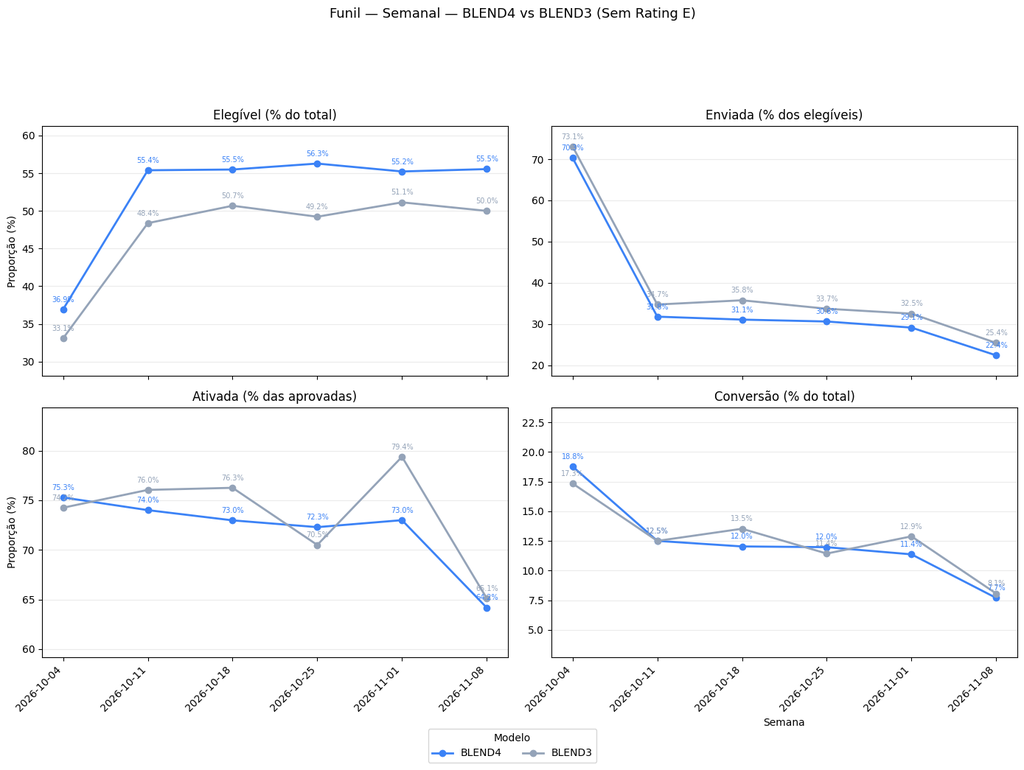

## Tabela de Conversão

Tabela de Conversão com Mix, Elegibilidade, Envio, Ativação, Conversão e Diferença de Conversão entre os modelos Blend3 e Blend4 em números e em percentual.

| bureau_nm_ajust year_week | mix BLEND3 | mix BLEND4 | elegivel BLEND3 | elegivel BLEND4 | enviada_elegivel BLEND3 | enviada_elegivel BLEND4 | ativada BLEND3 | ativada BLEND4 | conversao BLEND3 | conversao BLEND4 | diff_conversao |
| --- | --- | --- | --- | --- | --- | --- | --- | --- | --- | --- | --- |
| 2026-10-04 | 2,278 | 18,871 | 793 | 6,972 | 574 | 4,902 | 406 | 3,542 | 406 | 3,542 | 3,136 |
| 2026-10-11 | 2,768 | 24,069 | 1,393 | 13,332 | 479 | 4,237 | 349 | 3,009 | 349 | 3,009 | 2,660 |
| 2026-10-18 | 3,372 | 28,878 | 1,790 | 16,024 | 623 | 4,978 | 463 | 3,475 | 463 | 3,475 | 3,012 |
| 2026-10-25 | 3,490 | 29,354 | 1,790 | 16,520 | 594 | 5,056 | 402 | 3,514 | 402 | 3,514 | 3,112 |
| 2026-11-01 | 2,779 | 23,516 | 1,466 | 12,988 | 470 | 3,783 | 359 | 2,673 | 359 | 2,673 | 2,314 |
| 2026-11-08 | 2,630 | 22,893 | 1,356 | 12,716 | 336 | 2,847 | 211 | 1,761 | 212 | 1,761 | 1,549 |

| bureau_nm_ajust year_week | mix BLEND3 | mix BLEND4 | %_elegivel BLEND3 | %_elegivel BLEND4 | %_enviada_elegivel BLEND3 | %_enviada_elegivel BLEND4 | %_ativada BLEND3 | %_ativada BLEND4 | %_conversao BLEND3 | %_conversao BLEND4 | diff_conversao |
| --- | --- | --- | --- | --- | --- | --- | --- | --- | --- | --- | --- |
| 2026-10-04 | 10.77% | 89.23% | 34.81% | 36.95% | 72.38% | 70.31% | 73.68% | 75.28% | 17.82% | 18.77% | +0.95 pp |
| 2026-10-11 | 10.31% | 89.69% | 50.33% | 55.39% | 34.39% | 31.78% | 74.89% | 74.00% | 12.61% | 12.50% | -0.11 pp |
| 2026-10-18 | 10.46% | 89.54% | 53.08% | 55.49% | 34.80% | 31.07% | 76.03% | 72.97% | 13.73% | 12.03% | -1.70 pp |
| 2026-10-25 | 10.63% | 89.37% | 51.29% | 56.28% | 33.18% | 30.61% | 69.43% | 72.29% | 11.52% | 11.97% | +0.45 pp |
| 2026-11-01 | 10.57% | 89.43% | 52.75% | 55.23% | 32.06% | 29.13% | 78.21% | 72.99% | 12.92% | 11.37% | -1.55 pp |
| 2026-11-08 | 10.30% | 89.70% | 51.56% | 55.55% | 24.78% | 22.39% | 65.23% | 64.18% | 8.06% | 7.69% | -0.37 pp |

## Tabela de Conversão sem o Rating E

Tabela de Conversão com Mix, Elegibilidade, Envio, Ativação, Conversão e Diferença de Conversão entre os modelos Blend3 e Blend4 em números e em percentual, retirando o público com RATING E.

| bureau_nm_ajust year_week | mix BLEND3 | mix BLEND4 | elegivel BLEND3 | elegivel BLEND4 | enviada_elegivel BLEND3 | enviada_elegivel BLEND4 | ativada BLEND3 | ativada BLEND4 | conversao BLEND3 | conversao BLEND4 | diff_conversao |
| --- | --- | --- | --- | --- | --- | --- | --- | --- | --- | --- | --- |
| 2026-10-04 | 2,278 | 18,871 | 754 | 6,972 | 551 | 4,902 | 395 | 3,542 | 395 | 3,542 | 3,147 |
| 2026-10-11 | 2,768 | 24,069 | 1,339 | 13,332 | 465 | 4,237 | 346 | 3,009 | 346 | 3,009 | 2,663 |
| 2026-10-18 | 3,372 | 28,878 | 1,709 | 16,024 | 611 | 4,978 | 456 | 3,475 | 456 | 3,475 | 3,019 |
| 2026-10-25 | 3,490 | 29,354 | 1,718 | 16,520 | 579 | 5,056 | 399 | 3,514 | 399 | 3,514 | 3,115 |
| 2026-11-01 | 2,779 | 23,516 | 1,421 | 12,988 | 462 | 3,783 | 358 | 2,673 | 358 | 2,673 | 2,315 |
| 2026-11-08 | 2,630 | 22,893 | 1,315 | 12,716 | 334 | 2,847 | 211 | 1,761 | 212 | 1,761 | 1,549 |

| bureau_nm_ajust year_week | mix BLEND3 | mix BLEND4 | %_elegivel BLEND3 | %_elegivel BLEND4 | %_enviada_elegivel BLEND3 | %_enviada_elegivel BLEND4 | %_ativada BLEND3 | %_ativada BLEND4 | %_conversao BLEND3 | %_conversao BLEND4 | diff_conversao |
| --- | --- | --- | --- | --- | --- | --- | --- | --- | --- | --- | --- |
| 2026-10-04 | 10.77% | 89.23% | 33.10% | 36.95% | 73.08% | 70.31% | 74.25% | 75.28% | 17.34% | 18.77% | +1.43 pp |
| 2026-10-11 | 10.31% | 89.69% | 48.37% | 55.39% | 34.73% | 31.78% | 76.04% | 74.00% | 12.50% | 12.50% | +0.00 pp |
| 2026-10-18 | 10.46% | 89.54% | 50.68% | 55.49% | 35.75% | 31.07% | 76.25% | 72.97% | 13.52% | 12.03% | -1.49 pp |
| 2026-10-25 | 10.63% | 89.37% | 49.23% | 56.28% | 33.70% | 30.61% | 70.49% | 72.29% | 11.43% | 11.97% | +0.54 pp |
| 2026-11-01 | 10.57% | 89.43% | 51.13% | 55.23% | 32.51% | 29.13% | 79.38% | 72.99% | 12.88% | 11.37% | -1.52 pp |
| 2026-11-08 | 10.30% | 89.70% | 50.00% | 55.55% | 25.40% | 22.39% | 65.43% | 64.18% | 8.06% | 7.69% | -0.37 pp |

## Mix de Rating por Modelo: Blend 4 vs. Blend3

Mix de Rating por Modelo, considerando os 5 Rating's comparáveis.

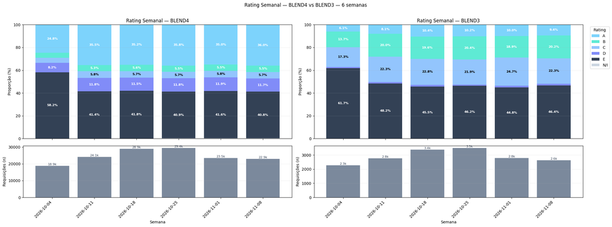

## Mix de Rating Política - Esperado vs. Produção

|  | safra | 1.A+ | 2.A | 3.B+ | 4.B | 5.C | 6.D+ | 7.D | 8.E | 9.E-BVS | volume |
| --- | --- | --- | --- | --- | --- | --- | --- | --- | --- | --- | --- |
| 11 | 2025-08 | 5.479852 | 11.252605 | 11.238394 | 11.356029 | 5.729331 | 5.888019 | 12.401314 | 26.162919 | 10.491537 | 126664 |

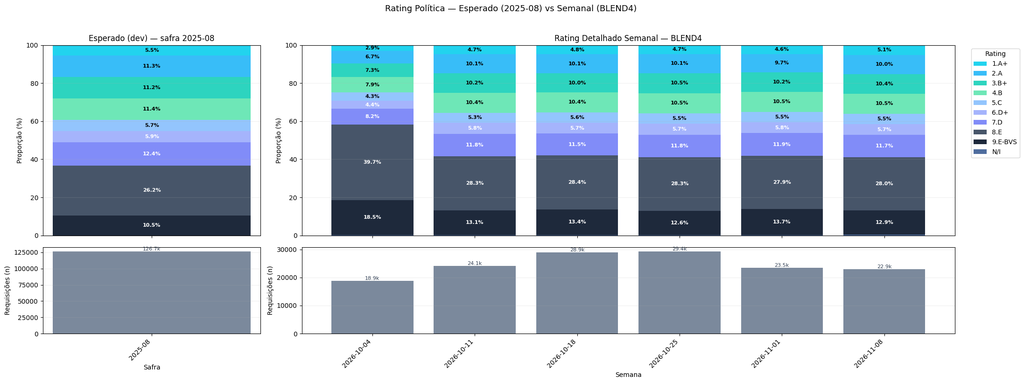

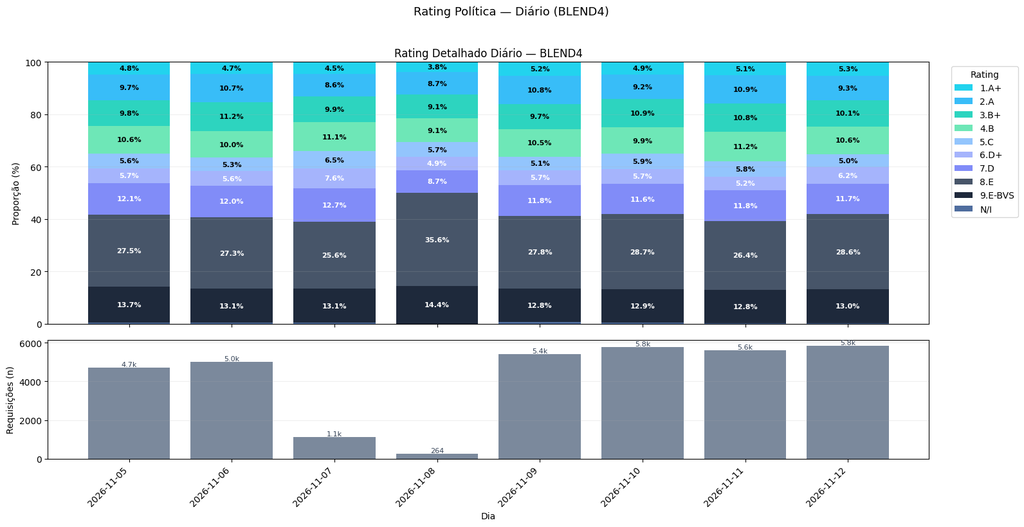

## Funil por Rating

Funil de Elegibilidade, Envio e Conversão comparado por Rating (A, B, C, D e E) em cada um dos Modelos: Blend3 e Blend4.

```
=== Elegível (%) — Semanal — por rating ===
```

| period | Blend 3 Rating A | Blend 3 Rating B | Blend 3 Rating C | Blend 3 Rating D | Blend 3 Rating E | Blend 4 Rating A | Blend 4 Rating B | Blend 4 Rating C | Blend 4 Rating D | Blend 4 Rating E | Blend 4 Rating N/I |
| --- | --- | --- | --- | --- | --- | --- | --- | --- | --- | --- | --- |
| 2026-10-04 | 94.3 | 86.8 | 83.2 | 87.5 | 2.8 | 92.0 | 83.8 | 74.8 | 68.6 | 2.6 | 100.0 |
| 2026-10-11 | 99.1 | 93.3 | 91.2 | 91.7 | 4.1 | 96.1 | 89.3 | 85.0 | 84.3 | 3.6 | 100.0 |
| 2026-10-18 | 98.9 | 91.8 | 91.9 | 84.0 | 5.3 | 96.3 | 91.1 | 86.0 | 83.9 | 4.2 | 100.0 |
| 2026-10-25 | 96.6 | 92.4 | 88.5 | 86.1 | 4.5 | 96.0 | 91.2 | 86.2 | 83.0 | 4.7 | 100.0 |
| 2026-11-01 | 97.5 | 92.4 | 91.0 | 89.2 | 3.6 | 95.9 | 90.8 | 85.7 | 82.9 | 3.8 | 100.0 |
| 2026-11-08 | 97.6 | 95.1 | 90.4 | 85.7 | 3.4 | 95.9 | 92.3 | 84.7 | 80.8 | 3.4 | 100.0 |

```
=== Envio (%) — Semanal — por rating ===
```

| period | Blend 3 Rating A | Blend 3 Rating B | Blend 3 Rating C | Blend 3 Rating D | Blend 3 Rating E | Blend 4 Rating A | Blend 4 Rating B | Blend 4 Rating C | Blend 4 Rating D | Blend 4 Rating E | Blend 4 Rating N/I |
| --- | --- | --- | --- | --- | --- | --- | --- | --- | --- | --- | --- |
| 2026-10-04 | 65.2 | 72.2 | 78.0 | 66.7 | 59.0 | 73.1 | 74.2 | 70.8 | 64.6 | 43.9 | 0.0 |
| 2026-10-11 | 28.4 | 35.2 | 37.2 | 33.3 | 25.9 | 34.1 | 38.4 | 32.9 | 22.5 | 19.0 | 3.0 |
| 2026-10-18 | 30.3 | 35.5 | 39.4 | 28.6 | 14.8 | 32.7 | 35.3 | 31.5 | 25.4 | 21.3 | 1.6 |
| 2026-10-25 | 24.6 | 38.9 | 33.5 | 35.5 | 20.8 | 32.5 | 36.2 | 33.6 | 22.6 | 19.5 | 1.4 |
| 2026-11-01 | 26.8 | 32.8 | 35.4 | 27.3 | 17.8 | 31.1 | 36.0 | 32.6 | 20.8 | 10.2 | 3.4 |
| 2026-11-08 | 18.8 | 24.8 | 29.4 | 22.2 | 4.9 | 23.7 | 27.6 | 22.6 | 17.3 | 10.3 | 0.0 |

```
=== Conversão (%) — Semanal — por rating ===
```

| period | Blend 3 Rating A | Blend 3 Rating B | Blend 3 Rating C | Blend 3 Rating D | Blend 3 Rating E | Blend 4 Rating A | Blend 4 Rating B | Blend 4 Rating C | Blend 4 Rating D | Blend 4 Rating E | Blend 4 Rating N/I |
| --- | --- | --- | --- | --- | --- | --- | --- | --- | --- | --- | --- |
| 2026-10-04 | 45.0 | 46.6 | 44.7 | 45.8 | 0.8 | 51.1 | 44.5 | 36.8 | 27.5 | 0.5 | 0.0 |
| 2026-10-11 | 21.9 | 24.2 | 25.3 | 19.4 | 0.2 | 24.1 | 25.9 | 18.5 | 12.2 | 0.2 | 0.0 |
| 2026-10-18 | 23.4 | 25.4 | 25.7 | 18.0 | 0.5 | 23.0 | 23.9 | 17.3 | 12.6 | 0.4 | 0.0 |
| 2026-10-25 | 15.4 | 24.7 | 21.0 | 19.4 | 0.2 | 22.7 | 23.8 | 19.7 | 11.2 | 0.2 | 0.0 |
| 2026-11-01 | 19.7 | 24.4 | 24.6 | 16.2 | 0.1 | 21.7 | 24.1 | 19.5 | 10.7 | 0.1 | 0.0 |
| 2026-11-08 | 11.8 | 16.6 | 15.0 | 16.7 | 0.0 | 14.7 | 16.3 | 11.0 | 7.5 | 0.1 | 0.0 |

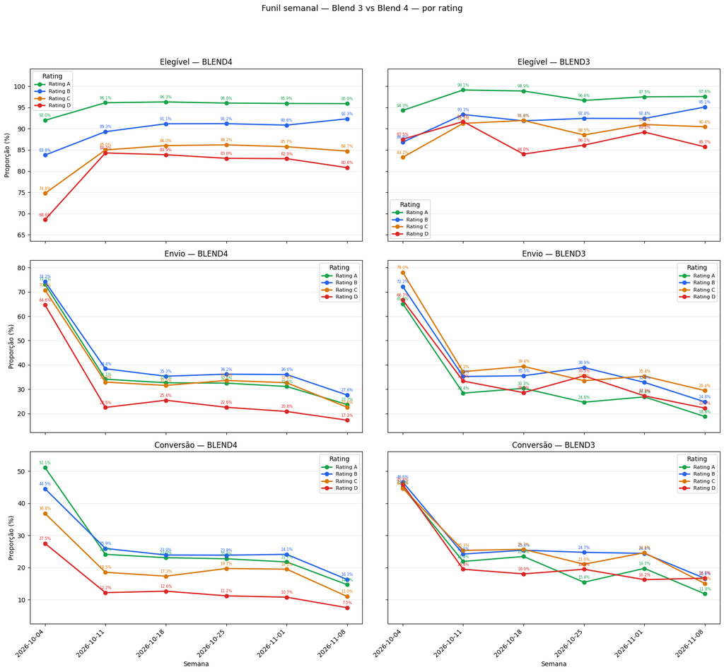

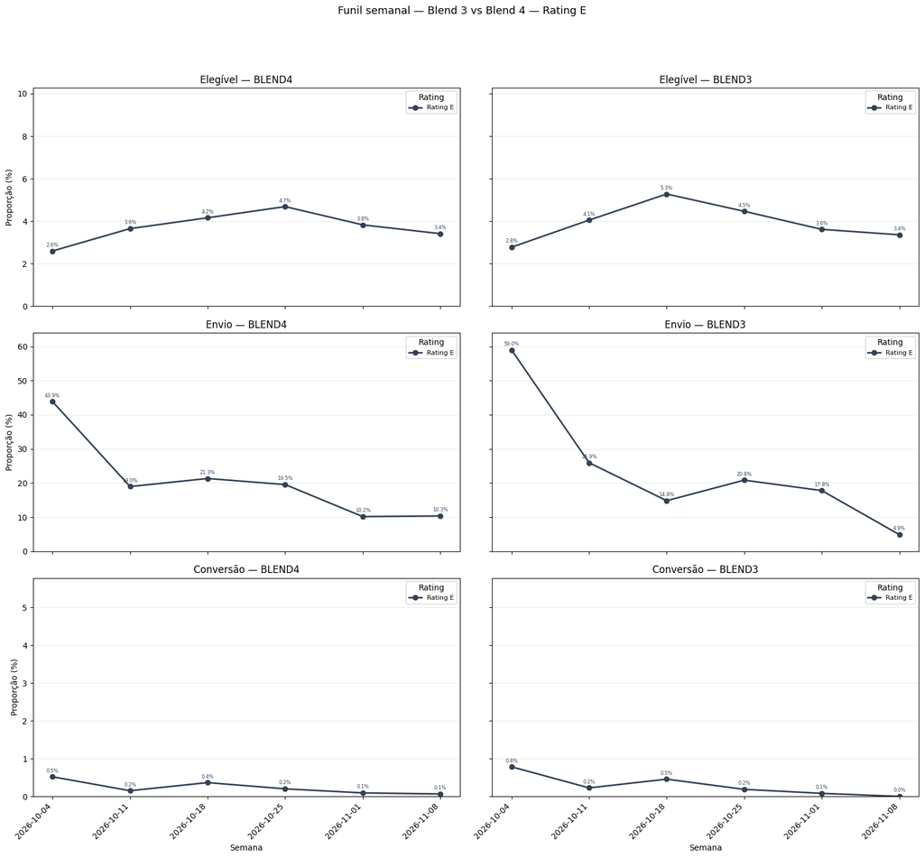

## Pré-Análise por Rating

Pré Análise (Aprovar, Derivar e Reprovar) aberto por Rating (A, B, C, D e E) e comparando os Modelos Blend3 e Blend4.

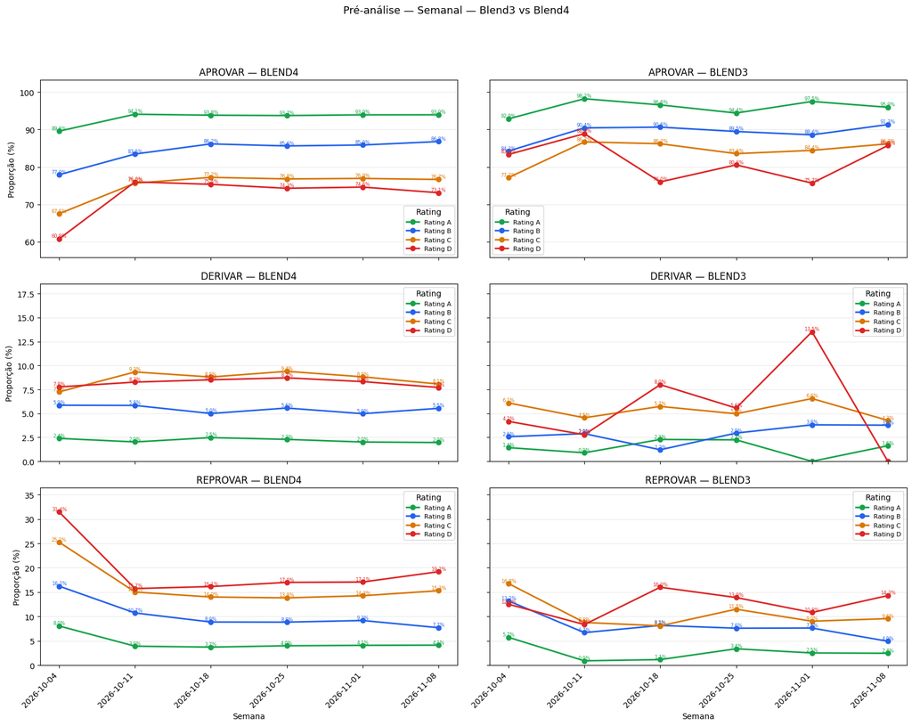

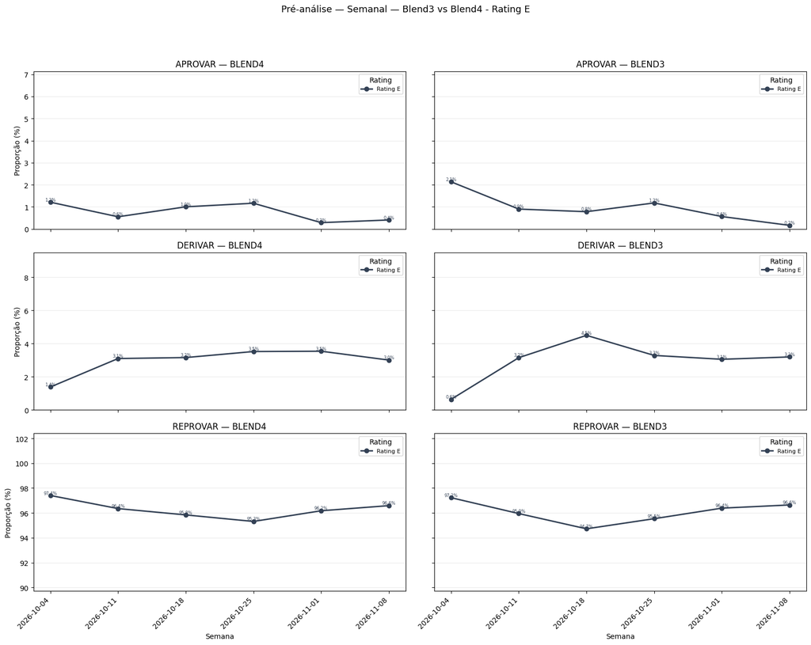

## Conversão Aprovados

```
Semanas: ['2026-10-04', '2026-10-11', '2026-10-18', '2026-10-25', '2026-11-01', '2026-11-08']
```

Baseline — Semana 2026-11-01

**Leads (Counts)**

| modelo decisao rating_score_group | BLEND3 APROVADO | BLEND3 DERIVADO | BLEND3 REPROVADO | BLEND4 APROVADO | BLEND4 DERIVADO | BLEND4 REPROVADO |
| --- | --- | --- | --- | --- | --- | --- |
| A | 272 | 0 | 7 | 7,730 | 166 | 335 |
| B | 465 | 20 | 40 | 1,105 | 64 | 118 |
| C | 580 | 45 | 62 | 1,047 | 120 | 194 |
| D | 28 | 5 | 4 | 2,090 | 233 | 478 |
| E | 7 | 38 | 1,200 | 28 | 346 | 9,403 |
| N/I | 0 | 6 | 0 | 0 | 59 | 0 |
| Total | 1,352 | 114 | 1,313 | 12,000 | 988 | 10,528 |

**Ativado / Lead (%)**

| modelo decisao rating_score_group | BLEND3 APROVADO | BLEND3 DERIVADO | BLEND3 REPROVADO | BLEND4 APROVADO | BLEND4 DERIVADO | BLEND4 REPROVADO |
| --- | --- | --- | --- | --- | --- | --- |
| A | 20.2% | nan% | 0.0% | 23.0% | 7.8% | 0.0% |
| B | 27.5% | 0.0% | 0.0% | 27.8% | 4.7% | 0.0% |
| C | 29.1% | 0.0% | 0.0% | 25.1% | 1.7% | 0.0% |
| D | 21.4% | 0.0% | 0.0% | 14.3% | 0.9% | 0.0% |
| E | 14.3% | 0.0% | 0.0% | 25.0% | 0.6% | 0.0% |
| N/I | nan% | 0.0% | nan% | nan% | 0.0% | nan% |
| Total | 26.6% | 0.0% | 0.0% | 22.1% | 2.2% | 0.0% |

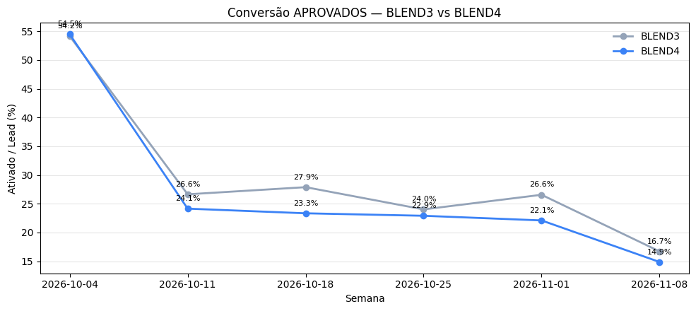

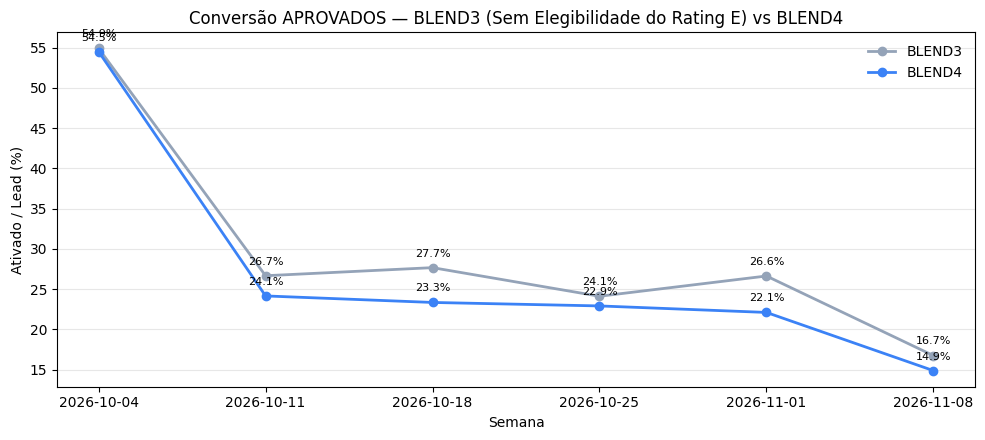

## Acompanhamento Renda

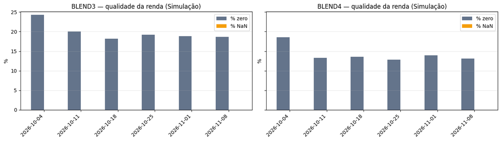

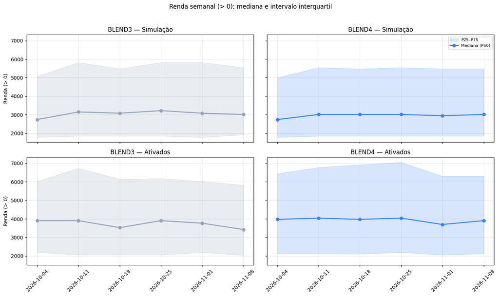

| rating_score_ds | contract_id |
| --- | --- |
| 8.E | 2 |
| 9.E-BVS | 20377 |
| N/I | 300 |

```
'bureau_nm_ajust'
```

## Mix de Cidades

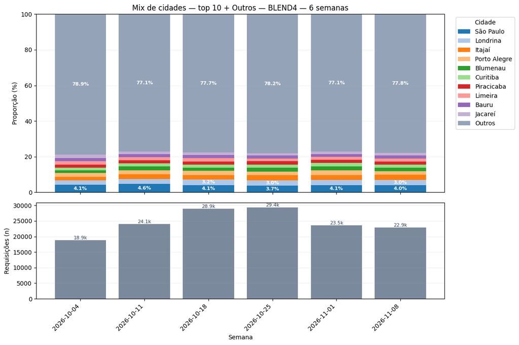

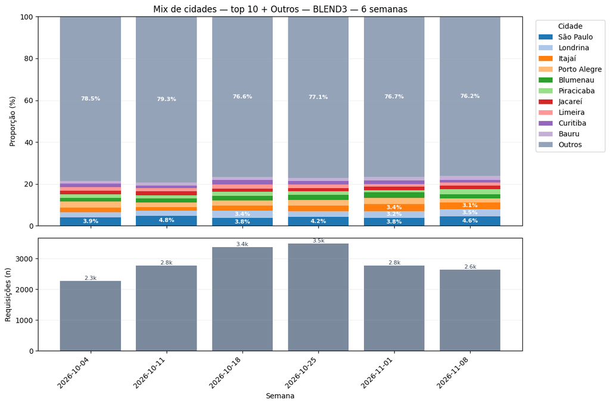

```
=== Cidades — BLEND4 | 2026-11-01 → 2026-11-08 ===
Já existiam e subiram para o top 10
```

|  | week_prev | week_curr | entity | n_prev | n_curr | share_prev_pct | share_curr_pct | delta_pp | rank_prev | rank_curr | rank_gain |
| --- | --- | --- | --- | --- | --- | --- | --- | --- | --- | --- | --- |
| 57 | 2026-11-01 | 2026-11-08 | Jacareí | 320 | 370 | 1.36 | 1.62 | 0.26 | 12 | 10 | 2 |
| 58 | 2026-11-01 | 2026-11-08 | Bauru | 351 | 372 | 1.49 | 1.62 | 0.13 | 11 | 9 | 2 |

```
Novas no top 10 (não estavam na semana anterior): nenhuma
Saíram do top 10
```

|  | week_prev | week_curr | entity | n_prev | n_curr | share_prev_pct | share_curr_pct | delta_pp | rank_prev | rank_curr | rank_gain |
| --- | --- | --- | --- | --- | --- | --- | --- | --- | --- | --- | --- |
| 56 | 2026-11-01 | 2026-11-08 | Rio de Janeiro | 368 | 290 | 1.56 | 1.27 | -0.30 | 9 | 14 | -5 |
| 55 | 2026-11-01 | 2026-11-08 | Goiânia | 368 | 303 | 1.56 | 1.32 | -0.24 | 9 | 13 | -4 |

```
Histórico WoW — Cidades — BLEND4
```

|  | week_prev | week_curr | entity | status | n_prev | n_curr | share_prev_pct | share_curr_pct | delta_pp | rank_prev | rank_curr | rank_gain |
| --- | --- | --- | --- | --- | --- | --- | --- | --- | --- | --- | --- | --- |
| 9 | 2026-10-04 | 2026-10-11 | Jacareí | saiu_do_top | 348 | 377 | 1.84 | 1.57 | -0.28 | 7 | 11 | -4 |
| 10 | 2026-10-04 | 2026-10-11 | Curitiba | subiu_para_top | 277 | 429 | 1.47 | 1.78 | 0.31 | 11 | 6 | 5 |
| 20 | 2026-10-11 | 2026-10-18 | Santa Maria | saiu_do_top | 383 | 420 | 1.59 | 1.45 | -0.14 | 9 | 11 | -2 |
| 21 | 2026-10-11 | 2026-10-18 | Jacareí | subiu_para_top | 377 | 442 | 1.57 | 1.53 | -0.04 | 11 | 10 | 1 |
| 30 | 2026-10-18 | 2026-10-25 | Jacareí | saiu_do_top | 442 | 372 | 1.53 | 1.27 | -0.26 | 10 | 17 | -7 |
| 31 | 2026-10-18 | 2026-10-25 | Limeira | saiu_do_top | 541 | 448 | 1.87 | 1.53 | -0.35 | 5 | 11 | -6 |
| 32 | 2026-10-18 | 2026-10-25 | São Carlos | subiu_para_top | 235 | 452 | 0.81 | 1.54 | 0.73 | 36 | 10 | 26 |
| 33 | 2026-10-18 | 2026-10-25 | Araçatuba | subiu_para_top | 304 | 475 | 1.05 | 1.62 | 0.57 | 18 | 9 | 9 |
| 41 | 2026-10-25 | 2026-11-01 | Bauru | saiu_do_top | 490 | 351 | 1.67 | 1.49 | -0.18 | 8 | 11 | -3 |
| 42 | 2026-10-25 | 2026-11-01 | Araçatuba | saiu_do_top | 475 | 197 | 1.62 | 0.84 | -0.78 | 9 | 29 | -20 |
| 43 | 2026-10-25 | 2026-11-01 | São Carlos | saiu_do_top | 452 | 162 | 1.54 | 0.69 | -0.85 | 10 | 43 | -33 |
| 44 | 2026-10-25 | 2026-11-01 | Goiânia | subiu_para_top | 393 | 368 | 1.34 | 1.56 | 0.23 | 13 | 9 | 4 |
| 45 | 2026-10-25 | 2026-11-01 | Limeira | subiu_para_top | 448 | 407 | 1.53 | 1.73 | 0.20 | 11 | 8 | 3 |
| 46 | 2026-10-25 | 2026-11-01 | Rio de Janeiro | subiu_para_top | 417 | 368 | 1.42 | 1.56 | 0.14 | 12 | 9 | 3 |
| 55 | 2026-11-01 | 2026-11-08 | Goiânia | saiu_do_top | 368 | 303 | 1.56 | 1.32 | -0.24 | 9 | 13 | -4 |
| 56 | 2026-11-01 | 2026-11-08 | Rio de Janeiro | saiu_do_top | 368 | 290 | 1.56 | 1.27 | -0.30 | 9 | 14 | -5 |
| 57 | 2026-11-01 | 2026-11-08 | Jacareí | subiu_para_top | 320 | 370 | 1.36 | 1.62 | 0.26 | 12 | 10 | 2 |
| 58 | 2026-11-01 | 2026-11-08 | Bauru | subiu_para_top | 351 | 372 | 1.49 | 1.62 | 0.13 | 11 | 9 | 2 |

```
=== Cidades — BLEND3 | 2026-11-01 → 2026-11-08 ===
Já existiam e subiram para o top 10
```

|  | week_prev | week_curr | entity | n_prev | n_curr | share_prev_pct | share_curr_pct | delta_pp | rank_prev | rank_curr | rank_gain |
| --- | --- | --- | --- | --- | --- | --- | --- | --- | --- | --- | --- |
| 56 | 2026-11-01 | 2026-11-08 | Piracicaba | 29 | 64 | 1.04 | 2.43 | 1.39 | 17 | 4 | 13 |
| 57 | 2026-11-01 | 2026-11-08 | Caxias do Sul | 36 | 45 | 1.30 | 1.71 | 0.42 | 12 | 8 | 4 |
| 58 | 2026-11-01 | 2026-11-08 | Limeira | 35 | 43 | 1.26 | 1.63 | 0.38 | 13 | 10 | 3 |

```
Novas no top 10 (não estavam na semana anterior): nenhuma
Saíram do top 10
```

|  | week_prev | week_curr | entity | n_prev | n_curr | share_prev_pct | share_curr_pct | delta_pp | rank_prev | rank_curr | rank_gain |
| --- | --- | --- | --- | --- | --- | --- | --- | --- | --- | --- | --- |
| 55 | 2026-11-01 | 2026-11-08 | Rio de Janeiro | 54 | 29 | 1.94 | 1.10 | -0.84 | 6 | 20 | -14 |
| 54 | 2026-11-01 | 2026-11-08 | Curitiba | 48 | 32 | 1.73 | 1.22 | -0.51 | 7 | 16 | -9 |
| 53 | 2026-11-01 | 2026-11-08 | Ribeirão Preto | 40 | 39 | 1.44 | 1.48 | 0.04 | 10 | 13 | -3 |

```
Histórico WoW — Cidades — BLEND3
```

|  | week_prev | week_curr | entity | status | n_prev | n_curr | share_prev_pct | share_curr_pct | delta_pp | rank_prev | rank_curr | rank_gain |
| --- | --- | --- | --- | --- | --- | --- | --- | --- | --- | --- | --- | --- |
| 9 | 2026-10-04 | 2026-10-11 | Curitiba | saiu_do_top | 35 | 37 | 1.54 | 1.34 | -0.20 | 10 | 12 | -2 |
| 10 | 2026-10-04 | 2026-10-11 | Bauru | subiu_para_top | 32 | 41 | 1.40 | 1.48 | 0.08 | 12 | 8 | 4 |
| 19 | 2026-10-11 | 2026-10-18 | Jacareí | saiu_do_top | 52 | 48 | 1.88 | 1.42 | -0.46 | 5 | 11 | -6 |
| 20 | 2026-10-11 | 2026-10-18 | Santa Maria | saiu_do_top | 60 | 39 | 2.17 | 1.16 | -1.01 | 4 | 15 | -11 |
| 21 | 2026-10-11 | 2026-10-18 | Curitiba | subiu_para_top | 37 | 72 | 1.34 | 2.14 | 0.80 | 12 | 5 | 7 |
| 22 | 2026-10-11 | 2026-10-18 | Araçatuba | subiu_para_top | 39 | 53 | 1.41 | 1.57 | 0.16 | 11 | 10 | 1 |
| 40 | 2026-10-25 | 2026-11-01 | Limeira | saiu_do_top | 56 | 35 | 1.60 | 1.26 | -0.35 | 8 | 13 | -5 |
| 41 | 2026-10-25 | 2026-11-01 | Piracicaba | saiu_do_top | 64 | 29 | 1.83 | 1.04 | -0.79 | 7 | 17 | -10 |
| 42 | 2026-10-25 | 2026-11-01 | Araçatuba | saiu_do_top | 76 | 20 | 2.18 | 0.72 | -1.46 | 6 | 41 | -35 |
| 43 | 2026-10-25 | 2026-11-01 | Rio de Janeiro | subiu_para_top | 40 | 54 | 1.15 | 1.94 | 0.80 | 17 | 6 | 11 |
| 44 | 2026-10-25 | 2026-11-01 | Ribeirão Preto | subiu_para_top | 45 | 40 | 1.29 | 1.44 | 0.15 | 15 | 10 | 5 |
| 45 | 2026-10-25 | 2026-11-01 | Jacareí | subiu_para_top | 55 | 47 | 1.58 | 1.69 | 0.12 | 11 | 8 | 3 |
| 53 | 2026-11-01 | 2026-11-08 | Ribeirão Preto | saiu_do_top | 40 | 39 | 1.44 | 1.48 | 0.04 | 10 | 13 | -3 |
| 54 | 2026-11-01 | 2026-11-08 | Curitiba | saiu_do_top | 48 | 32 | 1.73 | 1.22 | -0.51 | 7 | 16 | -9 |
| 55 | 2026-11-01 | 2026-11-08 | Rio de Janeiro | saiu_do_top | 54 | 29 | 1.94 | 1.10 | -0.84 | 6 | 20 | -14 |
| 56 | 2026-11-01 | 2026-11-08 | Piracicaba | subiu_para_top | 29 | 64 | 1.04 | 2.43 | 1.39 | 17 | 4 | 13 |
| 57 | 2026-11-01 | 2026-11-08 | Caxias do Sul | subiu_para_top | 36 | 45 | 1.30 | 1.71 | 0.42 | 12 | 8 | 4 |
| 58 | 2026-11-01 | 2026-11-08 | Limeira | subiu_para_top | 35 | 43 | 1.26 | 1.63 | 0.38 | 13 | 10 | 3 |

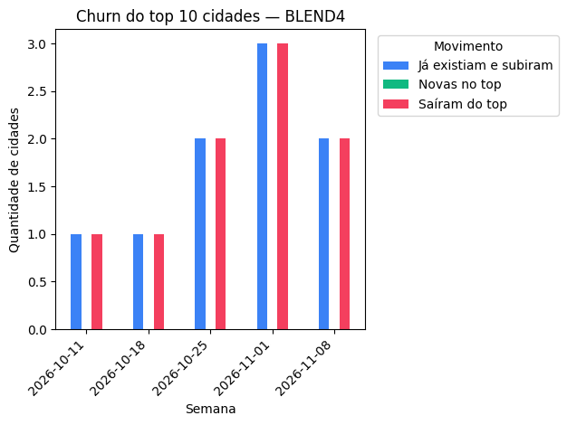

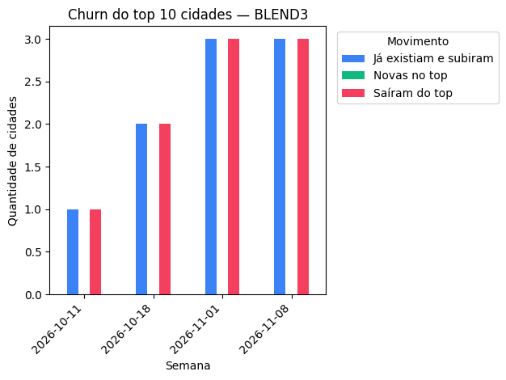

Trazer Estados ao invés da Cidade

## Mix de Imobiliárias

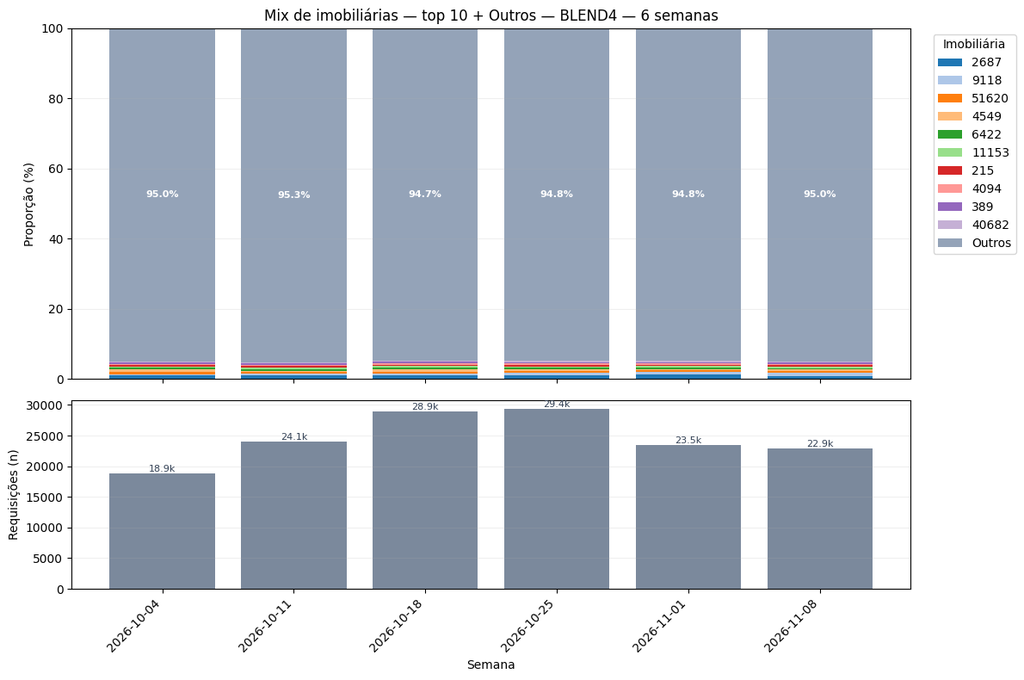

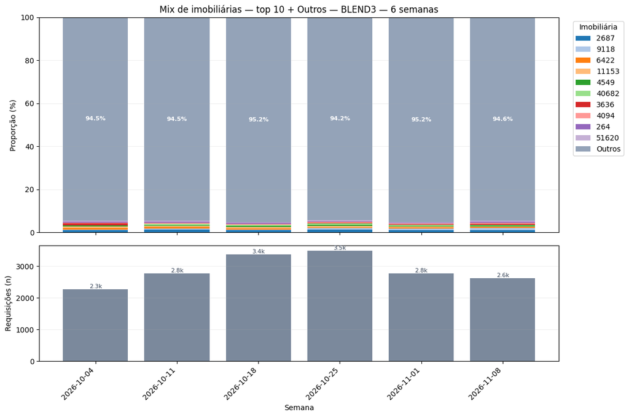

```
=== Imobiliárias — BLEND4 | 2026-11-01 → 2026-11-08 ===
Já existiam e subiram para o top 10
```

|  | week_prev | week_curr | entity | n_prev | n_curr | share_prev_pct | share_curr_pct | delta_pp | rank_prev | rank_curr | rank_gain |
| --- | --- | --- | --- | --- | --- | --- | --- | --- | --- | --- | --- |
| 68 | 2026-11-01 | 2026-11-08 | 13554 | 36 | 171 | 0.15 | 0.75 | 0.59 | 62.0 | 3.0 | 59.0 |
| 69 | 2026-11-01 | 2026-11-08 | 3636 | 38 | 92 | 0.16 | 0.40 | 0.24 | 59.0 | 9.0 | 50.0 |
| 70 | 2026-11-01 | 2026-11-08 | 6422 | 75 | 99 | 0.32 | 0.43 | 0.11 | 13.0 | 7.0 | 6.0 |
| 71 | 2026-11-01 | 2026-11-08 | 4881 | 76 | 91 | 0.32 | 0.40 | 0.07 | 11.0 | 10.0 | 1.0 |

```
Novas no top 10 (não estavam na semana anterior)
```

|  | week_prev | week_curr | entity | n_prev | n_curr | share_prev_pct | share_curr_pct | delta_pp | rank_prev | rank_curr | rank_gain |
| --- | --- | --- | --- | --- | --- | --- | --- | --- | --- | --- | --- |
| 57 | 2026-11-01 | 2026-11-08 | 55065 | 0 | 137 | 0.0 | 0.6 | 0.6 | NaN | 4.0 | NaN |

```
Saíram do top 10
```

|  | week_prev | week_curr | entity | n_prev | n_curr | share_prev_pct | share_curr_pct | delta_pp | rank_prev | rank_curr | rank_gain |
| --- | --- | --- | --- | --- | --- | --- | --- | --- | --- | --- | --- |
| 67 | 2026-11-01 | 2026-11-08 | 59038 | 117 | 0 | 0.50 | 0.00 | -0.50 | 5.0 | NaN | NaN |
| 66 | 2026-11-01 | 2026-11-08 | 13380 | 114 | 70 | 0.48 | 0.31 | -0.18 | 6.0 | 20.0 | -14.0 |
| 65 | 2026-11-01 | 2026-11-08 | 40682 | 99 | 79 | 0.42 | 0.35 | -0.08 | 7.0 | 15.0 | -8.0 |
| 64 | 2026-11-01 | 2026-11-08 | 215 | 85 | 85 | 0.36 | 0.37 | 0.01 | 10.0 | 13.0 | -3.0 |
| 63 | 2026-11-01 | 2026-11-08 | 4094 | 86 | 89 | 0.37 | 0.39 | 0.02 | 9.0 | 11.0 | -2.0 |

```
Histórico WoW — Imobiliárias — BLEND4
```

|  | week_prev | week_curr | entity | status | n_prev | n_curr | share_prev_pct | share_curr_pct | delta_pp | rank_prev | rank_curr | rank_gain |
| --- | --- | --- | --- | --- | --- | --- | --- | --- | --- | --- | --- | --- |
| 4 | 2026-10-04 | 2026-10-11 | 4549 | saiu_do_top | 106 | 94 | 0.56 | 0.39 | -0.17 | 7.0 | 13.0 | -6.0 |
| 5 | 2026-10-04 | 2026-10-11 | 53646 | saiu_do_top | 112 | 96 | 0.59 | 0.40 | -0.19 | 6.0 | 12.0 | -6.0 |
| 6 | 2026-10-04 | 2026-10-11 | 6422 | saiu_do_top | 116 | 99 | 0.61 | 0.41 | -0.20 | 5.0 | 11.0 | -6.0 |
| 7 | 2026-10-04 | 2026-10-11 | 13380 | saiu_do_top | 95 | 52 | 0.50 | 0.22 | -0.29 | 8.0 | 42.0 | -34.0 |
| 8 | 2026-10-04 | 2026-10-11 | 11913 | saiu_do_top | 121 | 74 | 0.64 | 0.31 | -0.33 | 4.0 | 21.0 | -17.0 |
| 9 | 2026-10-04 | 2026-10-11 | 3636 | saiu_do_top | 136 | 29 | 0.72 | 0.12 | -0.60 | 2.0 | 105.0 | -103.0 |
| 10 | 2026-10-04 | 2026-10-11 | 59038 | subiu_para_top | 50 | 132 | 0.26 | 0.55 | 0.28 | 29.0 | 2.0 | 27.0 |
| 11 | 2026-10-04 | 2026-10-11 | 264 | subiu_para_top | 42 | 114 | 0.22 | 0.47 | 0.25 | 37.0 | 4.0 | 33.0 |
| 12 | 2026-10-04 | 2026-10-11 | 4881 | subiu_para_top | 34 | 102 | 0.18 | 0.42 | 0.24 | 53.0 | 8.0 | 45.0 |
| 13 | 2026-10-04 | 2026-10-11 | 11153 | subiu_para_top | 55 | 103 | 0.29 | 0.43 | 0.14 | 24.0 | 6.0 | 18.0 |
| 14 | 2026-10-04 | 2026-10-11 | 389 | subiu_para_top | 64 | 100 | 0.34 | 0.42 | 0.08 | 16.0 | 10.0 | 6.0 |
| 15 | 2026-10-04 | 2026-10-11 | 215 | subiu_para_top | 75 | 107 | 0.40 | 0.44 | 0.05 | 11.0 | 5.0 | 6.0 |
| 22 | 2026-10-11 | 2026-10-18 | 215 | saiu_do_top | 107 | 112 | 0.44 | 0.39 | -0.06 | 5.0 | 11.0 | -6.0 |
| 23 | 2026-10-11 | 2026-10-18 | 4881 | saiu_do_top | 102 | 98 | 0.42 | 0.34 | -0.08 | 8.0 | 15.0 | -7.0 |
| 24 | 2026-10-11 | 2026-10-18 | 2164 | saiu_do_top | 101 | 82 | 0.42 | 0.28 | -0.14 | 9.0 | 22.0 | -13.0 |
| 25 | 2026-10-11 | 2026-10-18 | 59038 | saiu_do_top | 132 | 88 | 0.55 | 0.30 | -0.24 | 2.0 | 18.0 | -16.0 |
| 26 | 2026-10-11 | 2026-10-18 | 4549 | subiu_para_top | 94 | 186 | 0.39 | 0.64 | 0.25 | 13.0 | 2.0 | 11.0 |
| 27 | 2026-10-11 | 2026-10-18 | 4094 | subiu_para_top | 71 | 126 | 0.29 | 0.44 | 0.14 | 25.0 | 6.0 | 19.0 |
| 28 | 2026-10-11 | 2026-10-18 | 6422 | subiu_para_top | 99 | 159 | 0.41 | 0.55 | 0.14 | 11.0 | 3.0 | 8.0 |
| 29 | 2026-10-11 | 2026-10-18 | 969 | subiu_para_top | 75 | 118 | 0.31 | 0.41 | 0.10 | 20.0 | 10.0 | 10.0 |
| 30 | 2026-10-18 | 2026-10-25 | 641 | nova_no_top | 0 | 352 | 0.00 | 1.20 | 1.20 | NaN | 1.0 | NaN |
| 38 | 2026-10-18 | 2026-10-25 | 264 | saiu_do_top | 139 | 102 | 0.48 | 0.35 | -0.13 | 5.0 | 15.0 | -10.0 |
| 39 | 2026-10-18 | 2026-10-25 | 969 | saiu_do_top | 118 | 67 | 0.41 | 0.23 | -0.18 | 10.0 | 35.0 | -25.0 |
| 40 | 2026-10-18 | 2026-10-25 | 6422 | saiu_do_top | 159 | 102 | 0.55 | 0.35 | -0.20 | 3.0 | 15.0 | -12.0 |
| 41 | 2026-10-18 | 2026-10-25 | 6119 | subiu_para_top | 36 | 202 | 0.12 | 0.69 | 0.56 | 96.0 | 3.0 | 93.0 |
| 42 | 2026-10-18 | 2026-10-25 | 11913 | subiu_para_top | 48 | 119 | 0.17 | 0.41 | 0.24 | 61.0 | 8.0 | 53.0 |
| 43 | 2026-10-25 | 2026-11-01 | 59038 | nova_no_top | 0 | 117 | 0.00 | 0.50 | 0.50 | NaN | 5.0 | NaN |
| 50 | 2026-10-25 | 2026-11-01 | 389 | saiu_do_top | 112 | 70 | 0.38 | 0.30 | -0.08 | 10.0 | 16.0 | -6.0 |
| 51 | 2026-10-25 | 2026-11-01 | 11913 | saiu_do_top | 119 | 0 | 0.41 | 0.00 | -0.41 | 8.0 | NaN | NaN |
| 52 | 2026-10-25 | 2026-11-01 | 6119 | saiu_do_top | 202 | 21 | 0.69 | 0.09 | -0.60 | 3.0 | 160.0 | -157.0 |
| 53 | 2026-10-25 | 2026-11-01 | 641 | saiu_do_top | 352 | 24 | 1.20 | 0.10 | -1.10 | 1.0 | 128.0 | -127.0 |
| 54 | 2026-10-25 | 2026-11-01 | 13380 | subiu_para_top | 82 | 114 | 0.28 | 0.48 | 0.21 | 21.0 | 6.0 | 15.0 |
| 55 | 2026-10-25 | 2026-11-01 | 40682 | subiu_para_top | 110 | 99 | 0.37 | 0.42 | 0.05 | 11.0 | 7.0 | 4.0 |
| 56 | 2026-10-25 | 2026-11-01 | 215 | subiu_para_top | 110 | 85 | 0.37 | 0.36 | -0.01 | 11.0 | 10.0 | 1.0 |
| 57 | 2026-11-01 | 2026-11-08 | 55065 | nova_no_top | 0 | 137 | 0.00 | 0.60 | 0.60 | NaN | 4.0 | NaN |
| 63 | 2026-11-01 | 2026-11-08 | 4094 | saiu_do_top | 86 | 89 | 0.37 | 0.39 | 0.02 | 9.0 | 11.0 | -2.0 |
| 64 | 2026-11-01 | 2026-11-08 | 215 | saiu_do_top | 85 | 85 | 0.36 | 0.37 | 0.01 | 10.0 | 13.0 | -3.0 |
| 65 | 2026-11-01 | 2026-11-08 | 40682 | saiu_do_top | 99 | 79 | 0.42 | 0.35 | -0.08 | 7.0 | 15.0 | -8.0 |
| 66 | 2026-11-01 | 2026-11-08 | 13380 | saiu_do_top | 114 | 70 | 0.48 | 0.31 | -0.18 | 6.0 | 20.0 | -14.0 |
| 67 | 2026-11-01 | 2026-11-08 | 59038 | saiu_do_top | 117 | 0 | 0.50 | 0.00 | -0.50 | 5.0 | NaN | NaN |
| 68 | 2026-11-01 | 2026-11-08 | 13554 | subiu_para_top | 36 | 171 | 0.15 | 0.75 | 0.59 | 62.0 | 3.0 | 59.0 |
| 69 | 2026-11-01 | 2026-11-08 | 3636 | subiu_para_top | 38 | 92 | 0.16 | 0.40 | 0.24 | 59.0 | 9.0 | 50.0 |
| 70 | 2026-11-01 | 2026-11-08 | 6422 | subiu_para_top | 75 | 99 | 0.32 | 0.43 | 0.11 | 13.0 | 7.0 | 6.0 |
| 71 | 2026-11-01 | 2026-11-08 | 4881 | subiu_para_top | 76 | 91 | 0.32 | 0.40 | 0.07 | 11.0 | 10.0 | 1.0 |

```
=== Imobiliárias — BLEND3 | 2026-11-01 → 2026-11-08 ===
Já existiam e subiram para o top 10: nenhuma
Novas no top 10 (não estavam na semana anterior)
```

|  | week_prev | week_curr | entity | n_prev | n_curr | share_prev_pct | share_curr_pct | delta_pp | rank_prev | rank_curr | rank_gain |
| --- | --- | --- | --- | --- | --- | --- | --- | --- | --- | --- | --- |
| 19 | 2026-11-01 | 2026-11-08 | 13554 | 0 | 25 | 0.0 | 0.95 | 0.95 | NaN | 3.0 | NaN |

```
Saíram do top 10: nenhuma

Histórico WoW — Imobiliárias — BLEND3
```

|  | week_prev | week_curr | entity | status | n_prev | n_curr | share_prev_pct | share_curr_pct | delta_pp | rank_prev | rank_curr | rank_gain |
| --- | --- | --- | --- | --- | --- | --- | --- | --- | --- | --- | --- | --- |
| 0 | 2026-10-04 | 2026-10-11 | 6422 | nova_no_top | 0 | 21 | 0.00 | 0.76 | 0.76 | NaN | 2.0 | NaN |
| 2 | 2026-10-11 | 2026-10-18 | 11153 | nova_no_top | 0 | 21 | 0.00 | 0.62 | 0.62 | NaN | 2.0 | NaN |
| 3 | 2026-10-11 | 2026-10-18 | 389 | nova_no_top | 0 | 20 | 0.00 | 0.59 | 0.59 | NaN | 3.0 | NaN |
| 5 | 2026-10-11 | 2026-10-18 | 6422 | saiu_do_top | 21 | 0 | 0.76 | 0.00 | -0.76 | 2.0 | NaN | NaN |
| 6 | 2026-10-18 | 2026-10-25 | 641 | nova_no_top | 0 | 37 | 0.00 | 1.06 | 1.06 | NaN | 2.0 | NaN |
| 7 | 2026-10-18 | 2026-10-25 | 6119 | nova_no_top | 0 | 23 | 0.00 | 0.66 | 0.66 | NaN | 3.0 | NaN |
| 8 | 2026-10-18 | 2026-10-25 | 40682 | nova_no_top | 0 | 21 | 0.00 | 0.60 | 0.60 | NaN | 5.0 | NaN |
| 9 | 2026-10-18 | 2026-10-25 | 9118 | nova_no_top | 0 | 20 | 0.00 | 0.57 | 0.57 | NaN | 6.0 | NaN |
| 12 | 2026-10-18 | 2026-10-25 | 389 | saiu_do_top | 20 | 0 | 0.59 | 0.00 | -0.59 | 3.0 | NaN | NaN |
| 15 | 2026-10-25 | 2026-11-01 | 40682 | saiu_do_top | 21 | 0 | 0.60 | 0.00 | -0.60 | 5.0 | NaN | NaN |
| 16 | 2026-10-25 | 2026-11-01 | 11153 | saiu_do_top | 22 | 0 | 0.63 | 0.00 | -0.63 | 4.0 | NaN | NaN |
| 17 | 2026-10-25 | 2026-11-01 | 6119 | saiu_do_top | 23 | 0 | 0.66 | 0.00 | -0.66 | 3.0 | NaN | NaN |
| 18 | 2026-10-25 | 2026-11-01 | 641 | saiu_do_top | 37 | 0 | 1.06 | 0.00 | -1.06 | 2.0 | NaN | NaN |
| 19 | 2026-11-01 | 2026-11-08 | 13554 | nova_no_top | 0 | 25 | 0.00 | 0.95 | 0.95 | NaN | 3.0 | NaN |

[figure not shown]

[figure not shown]

## Salvar HTML

```
Report updated: /Users/lucas.nascimento/Monitoramento_Modelos/Monitores/02.Monitoramento_Funil_Blend4_report.html (3.34 MB) | generated at 2026-11-13 11:22:05 -03
If the browser still shows old content, hard-refresh (Cmd+Shift+R).
Report generated: /Users/lucas.nascimento/Monitoramento_Modelos/Monitores/02.Monitoramento_Funil_Blend4_report.html
```